# P9_Portfolio

**Сборный проект**

Интернет-магазин «Стримчик» продаёт по всему миру компьютерные игры. Из открытых источников доступны исторические данные (до 2016 года) о продажах игр, оценки пользователей и экспертов, жанры и платформы (например, Xbox или PlayStation). Представим, что сейчас декабрь 2016 г., и интернет-магазин планирует кампанию на 2017-й.

**Цель проекта:** выявить определяющие успешность игры закономерности. Это позволит сделать ставку на потенциально популярный продукт и спланировать рекламные кампании.

Описание данных

- Name — название игры
- Platform — платформа
- Year_of_Release — год выпуска
- Genre — жанр игры
- NA_sales — продажи в Северной Америке (миллионы проданных копий)
- EU_sales — продажи в Европе (миллионы проданных копий)
- JP_sales — продажи в Японии (миллионы проданных копий)
- Other_sales — продажи в других странах (миллионы проданных копий)
- Critic_Score — оценка критиков (максимум 100)
- User_Score — оценка пользователей (максимум 10)
- Rating — рейтинг от организации ESRB (англ. Entertainment Software Rating Board). Эта ассоциация определяет рейтинг компьютерных игр и присваивает им подходящую возрастную категорию.

В наборе данных попадается аббревиатура ESRB (Entertainment Software Rating Board) — это ассоциация, определяющая возрастной рейтинг компьютерных игр. ESRB оценивает игровой контент и присваивает ему подходящую возрастную категорию, например, «Для взрослых», «Для детей младшего возраста» или «Для подростков».

```python
pip install missingno
```

```python
import pandas as pd
import matplotlib.pyplot as plt
from scipy import stats as st
import numpy as np
from scipy.stats import binom
from math import sqrt
import missingno as msno
```

**Шаг 1. Загрузка данных**

Считаем CSV-файлы с данными с помощью библиотеки pandas и сохраним их в датафреймы. Выведем первые строки каждого набора данных. Изучим общую информацию о каждом датафрейме.

```python
data = pd.read_csv('/datasets/games.csv')
```

```python
data.info()
data.head(10)
```

```
<class 'pandas.core.frame.DataFrame'>
RangeIndex: 16715 entries, 0 to 16714
Data columns (total 11 columns):
 #   Column           Non-Null Count  Dtype
---  ------           --------------  -----
 0   Name             16713 non-null  object
 1   Platform         16715 non-null  object
 2   Year_of_Release  16446 non-null  float64
 3   Genre            16713 non-null  object
 4   NA_sales         16715 non-null  float64
 5   EU_sales         16715 non-null  float64
 6   JP_sales         16715 non-null  float64
 7   Other_sales      16715 non-null  float64
 8   Critic_Score     8137 non-null   float64
 9   User_Score       10014 non-null  object
 10  Rating           9949 non-null   object
dtypes: float64(6), object(5)
memory usage: 1.4+ MB
```

|  | Name | Platform | Year_of_Release | Genre | NA_sales | EU_sales | JP_sales | Other_sales | Critic_Score | User_Score | Rating |
| --- | --- | --- | --- | --- | --- | --- | --- | --- | --- | --- | --- |
| 0 | Wii Sports | Wii | 2006.0 | Sports | 41.36 | 28.96 | 3.77 | 8.45 | 76.0 | 8 | E |
| 1 | Super Mario Bros. | NES | 1985.0 | Platform | 29.08 | 3.58 | 6.81 | 0.77 | NaN | NaN | NaN |
| 2 | Mario Kart Wii | Wii | 2008.0 | Racing | 15.68 | 12.76 | 3.79 | 3.29 | 82.0 | 8.3 | E |
| 3 | Wii Sports Resort | Wii | 2009.0 | Sports | 15.61 | 10.93 | 3.28 | 2.95 | 80.0 | 8 | E |
| 4 | Pokemon Red/Pokemon Blue | GB | 1996.0 | Role-Playing | 11.27 | 8.89 | 10.22 | 1.00 | NaN | NaN | NaN |
| 5 | Tetris | GB | 1989.0 | Puzzle | 23.20 | 2.26 | 4.22 | 0.58 | NaN | NaN | NaN |
| 6 | New Super Mario Bros. | DS | 2006.0 | Platform | 11.28 | 9.14 | 6.50 | 2.88 | 89.0 | 8.5 | E |
| 7 | Wii Play | Wii | 2006.0 | Misc | 13.96 | 9.18 | 2.93 | 2.84 | 58.0 | 6.6 | E |
| 8 | New Super Mario Bros. Wii | Wii | 2009.0 | Platform | 14.44 | 6.94 | 4.70 | 2.24 | 87.0 | 8.4 | E |
| 9 | Duck Hunt | NES | 1984.0 | Shooter | 26.93 | 0.63 | 0.28 | 0.47 | NaN | NaN | NaN |

В каждом столбце должно быть 16715 заполненных поля. Видим, что

- пропуски есть в столбцах Name, Year_of_Release, Genre, Critic_Score, User_Score, Rating.
- название колонок с большой буквы, нужно будет изменить на строчные,
- тип данных Year_of_Release float однако года - целые числа. Далее поменяет на int
- тип данных User_Score object, хотя на первый взгляд должно быть float. Проверим далее уникальные значения.

**Шаг 2. Подготовьте данные**

2.1 Заменим названия столбцов (приведите к нижнему регистру), название стран остави без изменений, т.к. имя нарицательное.

```python
data.columns = data.columns.str.lower()
display(data.head(5))
```

|  | name | platform | year_of_release | genre | na_sales | eu_sales | jp_sales | other_sales | critic_score | user_score | rating |
| --- | --- | --- | --- | --- | --- | --- | --- | --- | --- | --- | --- |
| 0 | Wii Sports | Wii | 2006.0 | Sports | 41.36 | 28.96 | 3.77 | 8.45 | 76.0 | 8 | E |
| 1 | Super Mario Bros. | NES | 1985.0 | Platform | 29.08 | 3.58 | 6.81 | 0.77 | NaN | NaN | NaN |
| 2 | Mario Kart Wii | Wii | 2008.0 | Racing | 15.68 | 12.76 | 3.79 | 3.29 | 82.0 | 8.3 | E |
| 3 | Wii Sports Resort | Wii | 2009.0 | Sports | 15.61 | 10.93 | 3.28 | 2.95 | 80.0 | 8 | E |
| 4 | Pokemon Red/Pokemon Blue | GB | 1996.0 | Role-Playing | 11.27 | 8.89 | 10.22 | 1.00 | NaN | NaN | NaN |

2.2 Проверим датафреим на наличие дубликатов

```python
data.duplicated().sum()
```

```
0
```

2.3 Выведем количество пропущенных значений для каждого столбца.

```python
data.isna().sum()
```

```
name                  2
platform              0
year_of_release     269
genre                 2
na_sales              0
eu_sales              0
jp_sales              0
other_sales           0
critic_score       8578
user_score         6701
rating             6766
dtype: int64
```

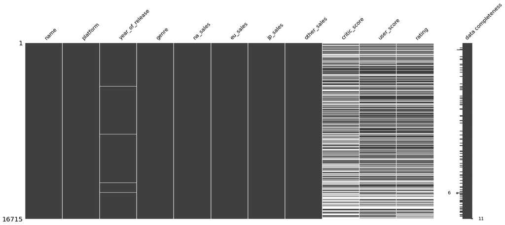

```python
msno.matrix(data, labels = True) # визуализируем пропуски
```

Скорее всего пропуски в столбцах name, year_of_release случайные, т.к. относительно всего массива данных процент пропусков в этих столбцах очень мал. А пропуски в столцах critic_score, user_score, rating неслучайные. Возможно поля в интернет сервисах были необязательными для сбора оценки игр, поэтому так много пропусков в этих колонках.

2.4 Строки с пропусками в столбцах name (2 пропуска), genre (2 пропуска), year_of_release (269 пропусков) удалим, т.к. их мало по сравнению с общим количеством строк 16715.

```python
data = data.dropna(subset=['name', 'year_of_release', 'genre'])
```

```python
data.isna().sum() # проверка
```

```
name                  0
platform              0
year_of_release       0
genre                 0
na_sales              0
eu_sales              0
jp_sales              0
other_sales           0
critic_score       8461
user_score         6605
rating             6676
dtype: int64
```

2.5 Преобразуем данные в колонке year_of_release из типа float в int.

```python
data['year_of_release'] = data['year_of_release'].astype('int32')
```

2.6 Посмотрим уникальные значения в столбцах с пропусками, проверим наличие анамальных значений и разброс значений.

```python
data['year_of_release'].unique()
```

```
array([2006, 1985, 2008, 2009, 1996, 1989, 1984, 2005, 1999, 2007, 2010,
       2013, 2004, 1990, 1988, 2002, 2001, 2011, 1998, 2015, 2012, 2014,
       1992, 1997, 1993, 1994, 1982, 2016, 2003, 1986, 2000, 1995, 1991,
       1981, 1987, 1980, 1983], dtype=int32)
```

Посмотрим график расспределения year_of_release

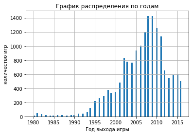

```python
data['year_of_release'].hist(bins=100)
plt.title('График распределения по годам')
plt.xlabel('Год выхода игры')
plt.ylabel('количество игр')
plt.show()
```

2.7 Посмотрим на уникальные значение platform и распределение

```python
data['platform'].unique()
```

```
array(['Wii', 'NES', 'GB', 'DS', 'X360', 'PS3', 'PS2', 'SNES', 'GBA',
       'PS4', '3DS', 'N64', 'PS', 'XB', 'PC', '2600', 'PSP', 'XOne',
       'WiiU', 'GC', 'GEN', 'DC', 'PSV', 'SAT', 'SCD', 'WS', 'NG', 'TG16',
       '3DO', 'GG', 'PCFX'], dtype=object)
```

```python
platforms = data.pivot_table(index='platform', values = 'year_of_release', aggfunc = 'count').reset_index()
platforms.columns = ['platform', 'platform_count']
platforms = platforms.sort_values(by = 'platform_count', ascending = False).reset_index()
display(platforms)
```

|  | index | platform | platform_count |
| --- | --- | --- | --- |
| 0 | 16 | PS2 | 2127 |
| 1 | 4 | DS | 2121 |
| 2 | 17 | PS3 | 1306 |
| 3 | 26 | Wii | 1286 |
| 4 | 28 | X360 | 1232 |
| 5 | 19 | PSP | 1193 |
| 6 | 15 | PS | 1190 |
| 7 | 13 | PC | 957 |
| 8 | 6 | GBA | 811 |
| 9 | 29 | XB | 803 |
| 10 | 7 | GC | 542 |
| 11 | 2 | 3DS | 512 |
| 12 | 20 | PSV | 429 |
| 13 | 18 | PS4 | 392 |
| 14 | 10 | N64 | 316 |
| 15 | 30 | XOne | 247 |
| 16 | 23 | SNES | 239 |
| 17 | 21 | SAT | 173 |
| 18 | 27 | WiiU | 147 |
| 19 | 0 | 2600 | 116 |
| 20 | 11 | NES | 98 |
| 21 | 5 | GB | 97 |
| 22 | 3 | DC | 52 |
| 23 | 8 | GEN | 27 |
| 24 | 12 | NG | 12 |
| 25 | 22 | SCD | 6 |
| 26 | 25 | WS | 6 |
| 27 | 1 | 3DO | 3 |
| 28 | 24 | TG16 | 2 |
| 29 | 14 | PCFX | 1 |
| 30 | 9 | GG | 1 |

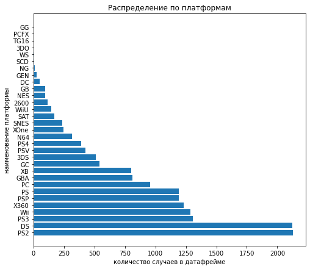

```python
fig, ax = plt.subplots(figsize=(8, 7))
plt.barh(platforms['platform'], platforms['platform_count'])
ax.set_title('Распределение по платформам')
ax.set_xlabel('количество случаев в датафрейме')
ax.set_ylabel('наименование платформы')
plt.show()
```

2.8 Посмотрим на уникальные занчения в столбце critic_score, посчитаем % пропусков и определим, что с ними делать.

```python
data['critic_score'].unique()
```

```
array([76., nan, 82., 80., 89., 58., 87., 91., 61., 97., 95., 77., 88.,
       83., 94., 93., 85., 86., 98., 96., 90., 84., 73., 74., 78., 92.,
       71., 72., 68., 62., 49., 67., 81., 66., 56., 79., 70., 59., 64.,
       75., 60., 63., 69., 50., 25., 42., 44., 55., 48., 57., 29., 47.,
       65., 54., 20., 53., 37., 38., 33., 52., 30., 32., 43., 45., 51.,
       40., 46., 39., 34., 41., 36., 31., 27., 35., 26., 19., 28., 23.,
       24., 21., 17., 13.])
```

Построим график распределения оценок критиков.

```python
critic_sort = data['critic_score'].sort_values()
display(critic_sort)
```

```
13689    13.0
10662    17.0
10015    19.0
15343    19.0
12131    19.0
         ...
16710     NaN
16711     NaN
16712     NaN
16713     NaN
16714     NaN
Name: critic_score, Length: 16444, dtype: float64
```

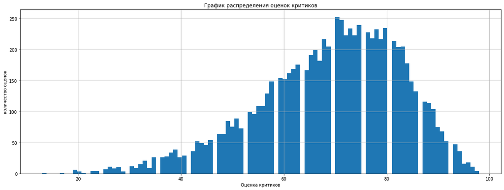

```python
critic_sort.hist(bins=100, figsize=(20, 7))
plt.title('График распределения оценок критиков')
plt.xlabel('Оценка критиков')
plt.ylabel('количество оценок')
plt.show()
```

Распределение норальное. Посчитаем какой % пропусков в critic_score. Из пункта 2.5 известно количество пропусков 8461.

```python
(8461/len(data))*100
```

```
51.453417659936754
```

51 % пропусков - большая доля от общего числа строк. Удалять нельзя, заменим на 0, такой оценки нет.

```python
data['critic_score'] = data['critic_score'].fillna(0)
data.info()
```

```
<class 'pandas.core.frame.DataFrame'>
Int64Index: 16444 entries, 0 to 16714
Data columns (total 11 columns):
 #   Column           Non-Null Count  Dtype
---  ------           --------------  -----
 0   name             16444 non-null  object
 1   platform         16444 non-null  object
 2   year_of_release  16444 non-null  int32
 3   genre            16444 non-null  object
 4   na_sales         16444 non-null  float64
 5   eu_sales         16444 non-null  float64
 6   jp_sales         16444 non-null  float64
 7   other_sales      16444 non-null  float64
 8   critic_score     16444 non-null  float64
 9   user_score       9839 non-null   object
 10  rating           9768 non-null   object
dtypes: float64(5), int32(1), object(5)
memory usage: 1.4+ MB
```

2.9 Посмотрим на уникальные значения, пропуски в столбце user_score.

```python
data['user_score'].sort_values().unique()
```

```
array(['0', '0.2', '0.3', '0.5', '0.6', '0.7', '0.9', '1', '1.1', '1.2',
       '1.3', '1.4', '1.5', '1.6', '1.7', '1.8', '1.9', '2', '2.1', '2.2',
       '2.3', '2.4', '2.5', '2.6', '2.7', '2.8', '2.9', '3', '3.1', '3.2',
       '3.3', '3.4', '3.5', '3.6', '3.7', '3.8', '3.9', '4', '4.1', '4.2',
       '4.3', '4.4', '4.5', '4.6', '4.7', '4.8', '4.9', '5', '5.1', '5.2',
       '5.3', '5.4', '5.5', '5.6', '5.7', '5.8', '5.9', '6', '6.1', '6.2',
       '6.3', '6.4', '6.5', '6.6', '6.7', '6.8', '6.9', '7', '7.1', '7.2',
       '7.3', '7.4', '7.5', '7.6', '7.7', '7.8', '7.9', '8', '8.1', '8.2',
       '8.3', '8.4', '8.5', '8.6', '8.7', '8.8', '8.9', '9', '9.1', '9.2',
       '9.3', '9.4', '9.5', '9.6', '9.7', 'tbd', nan], dtype=object)
```

Посмотрим график расспределения user_score

```python
users_sort = data['user_score'].sort_values()
```

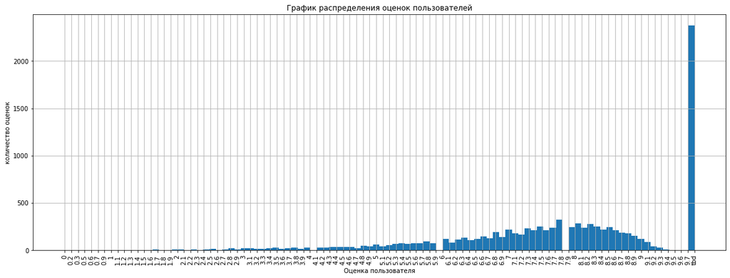

```python
users_sort.hist(bins=100, figsize=(20, 7))
plt.xticks(rotation='vertical')
plt.title('График распределения оценок пользователей')
plt.xlabel('Оценка пользователя')
plt.ylabel('количество оценок')
plt.show()
```

tbd (to be determined) переводится, как "оценка будет аннонсирована", однако данная информация не была получена, т.е. данные неизветсны. Посчитаем сколько оценок tbd.

```python
data.query('user_score == "tbd"').count()
```

```
name               2376
platform           2376
year_of_release    2376
genre              2376
na_sales           2376
eu_sales           2376
jp_sales           2376
other_sales        2376
critic_score       2376
user_score         2376
rating             2326
dtype: int64
```

2376 случаев. Посчитаем какой процент от общего количества строк в датафрейме.

```python
display((2376/len(data))*100)
```

```
14.449039163220629
```

Процент небольшой, однако согласно графику имеет наибольшее количество случаев. Для анализа данных будет мешать, поэтому уберем tbd из датафрейма.

```python
data = data[data['user_score'] != "tbd"]
data.query('user_score == "tbd"').count()
```

```
name               0
platform           0
year_of_release    0
genre              0
na_sales           0
eu_sales           0
jp_sales           0
other_sales        0
critic_score       0
user_score         0
rating             0
dtype: int64
```

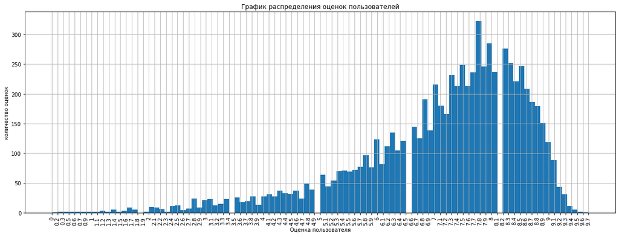

```python
data['user_score'].sort_values().hist(bins=100, figsize=(20, 7))
plt.xticks(rotation='vertical')
plt.title('График распределения оценок пользователей')
plt.xlabel('Оценка пользователя')
plt.ylabel('количество оценок')
plt.show()
```

Пропуски в user_score заменим на 0, 0 будем считать, что оценки нет.

```python
data['user_score'] = data['user_score'].fillna(0)
data.info()
```

```
<class 'pandas.core.frame.DataFrame'>
Int64Index: 14068 entries, 0 to 16714
Data columns (total 11 columns):
 #   Column           Non-Null Count  Dtype
---  ------           --------------  -----
 0   name             14068 non-null  object
 1   platform         14068 non-null  object
 2   year_of_release  14068 non-null  int32
 3   genre            14068 non-null  object
 4   na_sales         14068 non-null  float64
 5   eu_sales         14068 non-null  float64
 6   jp_sales         14068 non-null  float64
 7   other_sales      14068 non-null  float64
 8   critic_score     14068 non-null  float64
 9   user_score       14068 non-null  object
 10  rating           7442 non-null   object
dtypes: float64(5), int32(1), object(5)
memory usage: 1.2+ MB
```

Поменяем тип данные в столбце user_score на float

```python
data['user_score'] = data['user_score'].astype('float')
data.info()
```

```
<class 'pandas.core.frame.DataFrame'>
Int64Index: 14068 entries, 0 to 16714
Data columns (total 11 columns):
 #   Column           Non-Null Count  Dtype
---  ------           --------------  -----
 0   name             14068 non-null  object
 1   platform         14068 non-null  object
 2   year_of_release  14068 non-null  int32
 3   genre            14068 non-null  object
 4   na_sales         14068 non-null  float64
 5   eu_sales         14068 non-null  float64
 6   jp_sales         14068 non-null  float64
 7   other_sales      14068 non-null  float64
 8   critic_score     14068 non-null  float64
 9   user_score       14068 non-null  float64
 10  rating           7442 non-null   object
dtypes: float64(6), int32(1), object(4)
memory usage: 1.2+ MB
```

2.10 Посмотрим уникальные значения, пропуски в столце rating.

```python
data['rating'].unique() # уникальные занчения рейтинга
```

```
array(['E', nan, 'M', 'T', 'E10+', 'K-A', 'AO', 'EC', 'RP'], dtype=object)
```

Пропуски в колонке rating заменим на Unknown.

```python
data['rating'] = data['rating'].fillna('Unknown')
data['rating'].unique()
```

```
array(['E', 'Unknown', 'M', 'T', 'E10+', 'K-A', 'AO', 'EC', 'RP'],
      dtype=object)
```

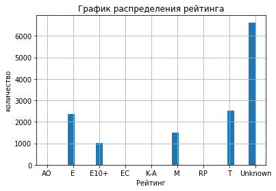

```python
data = data.sort_values(by = 'rating')
data['rating'].hist(bins=30)
plt.title('График распределения рейтинга')
plt.xlabel('Рейтинг')
plt.ylabel('количество')
plt.show()
```

Часто встречается рейтинг Unknown, редко AO (Adults Only 18+/Только для взрослых), EC (Early childhood/Для детей младшего возраста), K-A (Kids to Adults/Дети и взрослые), RP (Rating Pending/Рейтинг ожидается).

2.11 Посмотрим уникальные значения в столце genre.

```python
data['genre'].unique() # уникальные занчения жанров
```

```
array(['Action', 'Sports', 'Platform', 'Racing', 'Simulation', 'Misc',
       'Adventure', 'Puzzle', 'Shooter', 'Strategy', 'Role-Playing',
       'Fighting'], dtype=object)
```

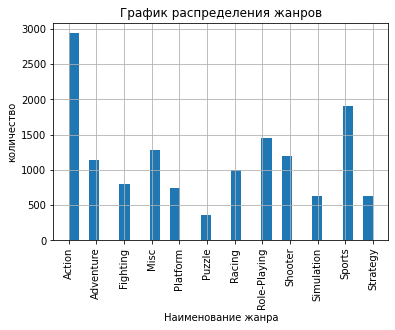

```python
data = data.sort_values(by = 'genre')
data['genre'].hist(bins=30)
plt.xticks(rotation='vertical')
plt.title('График распределения жанров')
plt.xlabel('Наименование жанра')
plt.ylabel('количество')
plt.show()
```

Наибольшее число игр в жанре Action, наименьшее в Puzzle.

2.12 Посчитаем суммарные продажи во всех регионах и запишите их в отдельный столбец.

```python
data['revenue'] = data[['na_sales', 'eu_sales', 'jp_sales', 'other_sales']].sum(axis=1)
data.head(5)
```

|  | name | platform | year_of_release | genre | na_sales | eu_sales | jp_sales | other_sales | critic_score | user_score | rating | revenue |
| --- | --- | --- | --- | --- | --- | --- | --- | --- | --- | --- | --- | --- |
| 875 | Grand Theft Auto: San Andreas | XB | 2005 | Action | 1.26 | 0.61 | 0.00 | 0.09 | 93.0 | 8.6 | AO | 1.96 |
| 545 | Saints Row: The Third | X360 | 2011 | Action | 1.25 | 1.14 | 0.07 | 0.30 | 84.0 | 7.6 | M | 2.76 |
| 16530 | Carmageddon: Max Damage | PS4 | 2016 | Action | 0.01 | 0.00 | 0.00 | 0.00 | 51.0 | 5.5 | M | 0.01 |
| 4935 | Hitman: Blood Money | X360 | 2006 | Action | 0.29 | 0.06 | 0.01 | 0.03 | 82.0 | 8.7 | M | 0.39 |
| 7639 | Dying Light | PC | 2015 | Action | 0.12 | 0.06 | 0.00 | 0.02 | 75.0 | 7.9 | M | 0.20 |

Вывод по шагу 2.

В данном разделе:

- привели название столбцов к нижнему регистру,
- проверили наличие дубликатов - не найдено,
- нашли пропуски - некоторые удалили (в столбцах name, year_of_release, genre), некоторые заменили (в столбцах user_score, critical_score, rating),
- поменяли тип данных в столбцах year_of_release на int, user_score на float,
- вывели уникальные значения в колонках и распределение,
- обнаружили, что в колонке user_score была самая часто встречаемая оценка tbd, от которой избавились,
- обнаружили, что часто встречается рейтинг Unknown,
- посчитали суммарные продажи во всех регионах в отдельном столбце.

**Шаг 3. Проведите исследовательский анализ данных**

3.1 Посмотрим, сколько игр выпускалось в разные годы.

|  | year_of_release | genre |
| --- | --- | --- |
| 0 | 1980 | 9 |
| 1 | 1981 | 46 |
| 2 | 1982 | 36 |
| 3 | 1983 | 17 |
| 4 | 1984 | 14 |
| 5 | 1985 | 14 |
| 6 | 1986 | 21 |
| 7 | 1987 | 16 |
| 8 | 1988 | 15 |
| 9 | 1989 | 17 |
| 10 | 1990 | 16 |
| 11 | 1991 | 41 |
| 12 | 1992 | 43 |
| 13 | 1993 | 60 |
| 14 | 1994 | 121 |
| 15 | 1995 | 219 |
| 16 | 1996 | 263 |
| 17 | 1997 | 288 |
| 18 | 1998 | 379 |
| 19 | 1999 | 330 |
| 20 | 2000 | 307 |
| 21 | 2001 | 400 |
| 22 | 2002 | 637 |
| 23 | 2003 | 680 |
| 24 | 2004 | 655 |
| 25 | 2005 | 818 |
| 26 | 2006 | 882 |
| 27 | 2007 | 1005 |
| 28 | 2008 | 1101 |
| 29 | 2009 | 1021 |
| 30 | 2010 | 924 |
| 31 | 2011 | 919 |
| 32 | 2012 | 629 |
| 33 | 2013 | 529 |
| 34 | 2014 | 560 |
| 35 | 2015 | 568 |
| 36 | 2016 | 468 |

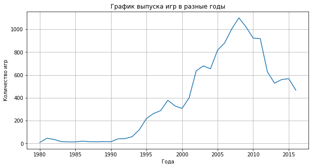

```python
play_count = data.groupby('year_of_release')['genre'].count()
play_count.columns = ['year_of_release', 'play_count']
display(play_count.reset_index())
play_count.plot(x='year_of_release', y='genre', figsize = (10, 5), grid = True)
plt.title('График выпуска игр в разные годы')
plt.xlabel('Года')
plt.ylabel('Количество игр')
plt.show()
```

Данные приведены с 1980 г. и до 2016 г. С 1980 по 2008 года количество игр увеличивалось с 9 до 1101 (максимум), далее количество пошло на убыль. С 1980 по 1993 рост медленный. Возьмем для анализа данные за последние 3 года, т.к. сфера игр быстро изменяющаяся.

```python
data = data.query('year_of_release > 2013')
```

3.2 Посмотрим, как менялись продажи по платформам. Выберем платформы с наибольшими суммарными продажами и построим распределение по годам. За какой характерный срок появляются новые и исчезают старые платформы?

```python
platform_sort = data.groupby('platform')['revenue'].sum()
platform_sort.columns = ['platform', 'revenue_sum']
platform_sort.sort_values().reset_index()
```

|  | platform | revenue |
| --- | --- | --- |
| 0 | PSP | 0.36 |
| 1 | Wii | 2.76 |
| 2 | PSV | 22.09 |
| 3 | PC | 26.96 |
| 4 | WiiU | 42.58 |
| 5 | X360 | 46.86 |
| 6 | PS3 | 66.86 |
| 7 | 3DS | 85.38 |
| 8 | XOne | 139.81 |
| 9 | PS4 | 288.01 |

Наибольшие суммарные продажами у платформ PS4, XOne, 3DS. Построим для этих платформ распределение выручки по годам.

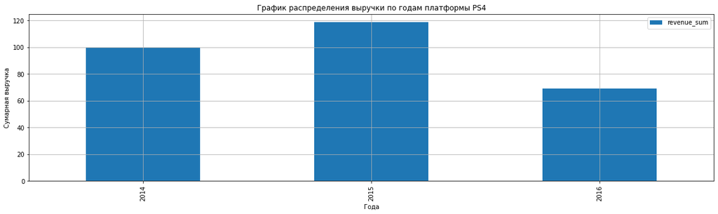

```python
PS4_revenue = data.query('platform == "PS4"') # для платформы PS4
PS4_revenue = PS4_revenue.groupby('year_of_release')['revenue'].sum().reset_index()
PS4_revenue.columns = ['year_of_release', 'revenue_sum']
PS4_revenue.plot(x='year_of_release', y='revenue_sum', kind= 'bar', figsize = (20,5), grid = True)
plt.title('График распределения выручки по годам платформы PS4')
plt.xlabel('Года')
plt.ylabel('Сумарная выручка')
plt.show()
```

Максимальная выручка платформы PS4 была в 2015 году.

Построим распределение выручки по годам для платформы XOne.

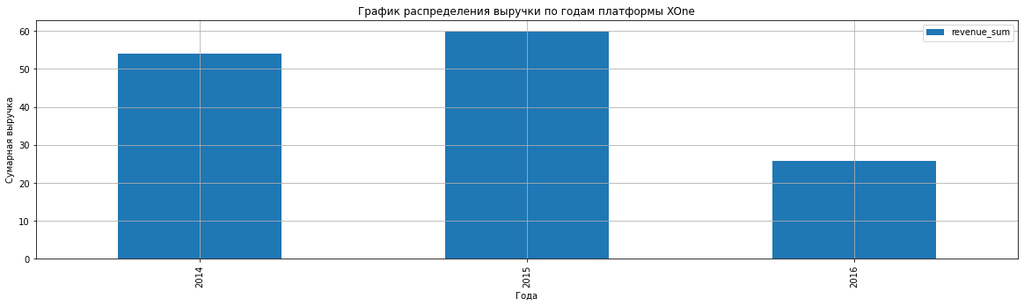

```python
XOne_revenue = data.query('platform == "XOne"') # для платформы XOne
XOne_revenue = XOne_revenue.groupby('year_of_release')['revenue'].sum().reset_index()
XOne_revenue.columns = ['year_of_release', 'revenue_sum']
XOne_revenue.plot(x='year_of_release', y='revenue_sum', kind= 'bar', figsize = (20,5), grid = True)
plt.title('График распределения выручки по годам платформы XOne')
plt.xlabel('Года')
plt.ylabel('Сумарная выручка')
plt.show()
```

Максимальная выручка платформы XOne была в 2015 году.

Построим распределение выручки по годам для платформы 3DS.

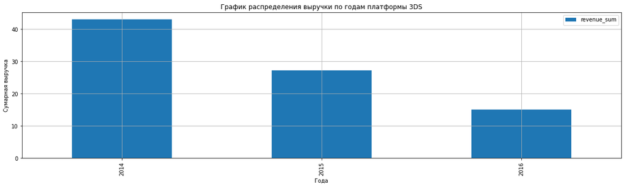

```python
DS3_revenue = data.query('platform == "3DS"') # для платформы X360
DS3_revenue = DS3_revenue.groupby('year_of_release')['revenue'].sum().reset_index()
DS3_revenue.columns = ['year_of_release', 'revenue_sum']
DS3_revenue.plot(x='year_of_release', y='revenue_sum', kind= 'bar', figsize = (20,5), grid = True)
plt.title('График распределения выручки по годам платформы 3DS')
plt.xlabel('Года')
plt.ylabel('Сумарная выручка')
plt.show()
```

Максимальная выручка платформы 3DS была в 2014 году.

Определим за какой характерный срок появляются новые и исчезают старые платформы

```
array(['3DS', 'PC', 'PS3', 'PS4', 'PSP', 'PSV', 'Wii', 'WiiU', 'X360',
       'XOne'], dtype=object)
```

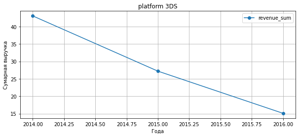

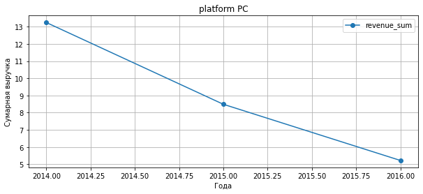

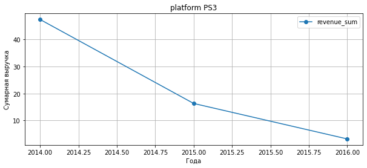

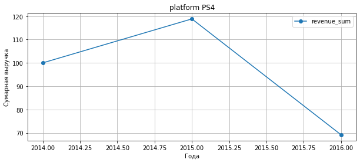

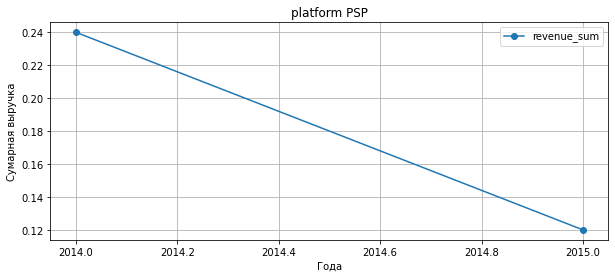

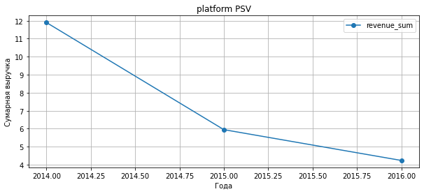

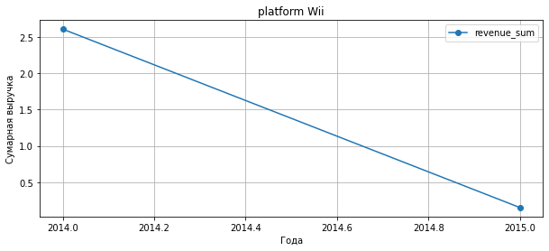

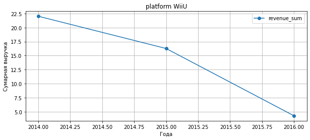

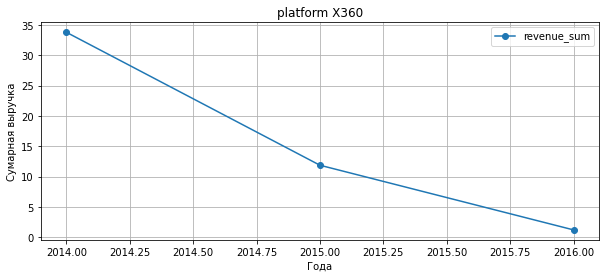

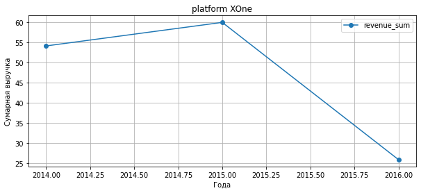

```python
platform_pivot = data.pivot_table(index=['platform', 'year_of_release'], values = 'revenue', aggfunc = 'sum').reset_index()
platform_pivot.columns = ['platform', 'year_of_release', 'revenue_sum']
display(platform_pivot['platform'].unique())

for i in platform_pivot['platform'].unique():
    platform_pivot.query(f"platform == '{i}'").plot(x='year_of_release', y='revenue_sum', style = 'o-', figsize=(10, 4), grid = True, legend = True)
    plt.title(f"platform {i}")
    plt.xlabel('Года')
    plt.ylabel('Сумарная выручка')
    plt.show()
```

В 2015 году ушли с рынка платформы PSP, Wii. Платформы XOne, PS4 прошли пик популярности в 2015 году, после чего прибыль пошла на убыль, т.е. ориентировочно платформы за 2 года набирают популярность. Когда появляются новые платформы, старые теряют популярность, велик риск, что в такие моменты старые платформы могут уйти с рынка.

3.3 Возьмите данные за соответствующий актуальный период. Актуальный период определите самостоятельно в результате исследования предыдущих вопросов. Основной фактор — эти данные помогут построить прогноз на 2017 год. Какие платформы лидируют по продажам, растут или падают? Выберите несколько потенциально прибыльных платформ.

Актуальный период оставим с 2014 года. Из имеющихся данных видно, что у всех существующих платформ идет спад в продажах.

Продажи платформ PS3, Х360 к 2016 году опустилась до 0 или близко к 0.

Прибыль платформ PC, WiiU, PSV опустилась ближе к 5 млн. к 2016 году.

Наиболее перспективные платформы по прибыли на 2016 год - XOne, PS4, 3DS.

3.4 Постройте график «ящик с усами» по глобальным продажам игр в разбивке по платформам. Опишите результат.

Рассмотрим 5 наиболее перспективных платформ: XOne, PS4, 3DS, X360, PS3.

| year_of_release | platform genre | XOne | PS4 | 3DS | X360 | PS3 |
| --- | --- | --- | --- | --- | --- | --- |
| 2014 | Action | 0.814762 | 1.405484 | 0.154348 | 0.451667 | 0.430000 |
|  | Adventure | 0.092000 | 0.295000 | 0.046667 | 0.103333 | 0.074545 |
|  | Fighting | NaN | 0.160000 | 3.835000 | 0.107500 | 0.215000 |
|  | Misc | 0.550000 | 1.108000 | 0.218000 | 0.345000 | 1.198000 |
|  | Platform | 0.340000 | 1.465000 | 1.605000 | NaN | 0.325000 |
|  | Puzzle | NaN | NaN | 0.110000 | NaN | 0.040000 |
|  | Racing | 0.760000 | 1.100000 | NaN | 0.258333 | 0.156000 |
|  | Role-Playing | 0.603333 | 0.685000 | 1.306316 | 0.460000 | 0.300000 |
|  | Shooter | 1.978000 | 3.042857 | NaN | 1.025455 | 0.969000 |
|  | Simulation | NaN | NaN | 0.203333 | 0.050000 | 0.020000 |
|  | Sports | 0.789000 | 1.394545 | 0.295000 | 1.180000 | 0.849167 |
|  | Strategy | NaN | 0.050000 | 0.136667 | NaN | 0.060000 |
| 2015 | Action | 0.364615 | 0.650196 | 0.388485 | 0.249091 | 0.174828 |
|  | Adventure | 0.341667 | 0.297000 | 0.043333 | 0.312500 | 0.124286 |
|  | Fighting | 0.600000 | 0.536667 | 0.200000 | 0.230000 | 0.145000 |
|  | Misc | 0.532500 | 0.407500 | 0.226000 | 0.270000 | 0.160000 |
|  | Platform | NaN | 0.165000 | 0.146667 | 0.090000 | NaN |
|  | Puzzle | NaN | 0.020000 | 0.216667 | NaN | NaN |
|  | Racing | 0.521667 | 0.914000 | NaN | 0.010000 | 0.050000 |
|  | Role-Playing | 1.060000 | 0.701200 | 0.456000 | NaN | 0.154000 |
|  | Shooter | 2.174545 | 2.997273 | NaN | 0.780000 | 0.820000 |
|  | Simulation | 0.200000 | 0.340000 | 1.073333 | 0.360000 | 0.370000 |
|  | Sports | 0.798333 | 1.339333 | 0.140000 | 0.478889 | 0.627778 |
|  | Strategy | 0.210000 | 0.080000 | 0.077500 | NaN | NaN |
| 2016 | Action | 0.141290 | 0.251695 | 0.256500 | 0.160000 | 0.074545 |
|  | Adventure | 0.056667 | 0.167692 | 0.100000 | 0.030000 | 0.090000 |
|  | Fighting | 0.185000 | 0.391429 | 0.030000 | NaN | 0.080000 |
|  | Misc | 0.030000 | 0.075714 | 0.100000 | NaN | 0.034000 |
|  | Platform | 0.093333 | 0.432000 | 0.150000 | NaN | NaN |
|  | Racing | 0.164444 | 0.132222 | NaN | NaN | NaN |
|  | Role-Playing | 0.330000 | 0.332222 | 1.194286 | NaN | 0.092000 |
|  | Shooter | 0.888462 | 1.272105 | NaN | NaN | 0.020000 |
|  | Simulation | 0.010000 | 0.137500 | 0.110000 | NaN | NaN |
|  | Sports | 0.562727 | 0.911250 | NaN | 0.177500 | 0.204286 |
|  | Strategy | 0.040000 | 0.110000 | 0.060000 | NaN | NaN |

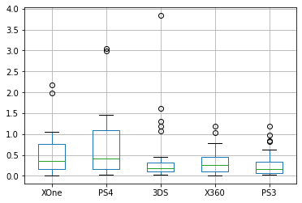

```python
platform_box = data.pivot_table(index=['year_of_release', 'genre'], columns = 'platform', values ='revenue')
platform_box = platform_box.loc[:, ['XOne', 'PS4', '3DS', 'X360', 'PS3']]
display(platform_box)
platform_box.boxplot()
```

Наибольша медиана продаж у платформы PS4 (около 0.5 млн. копий), далее в порядке убывания XOne, X360, 3DS, PS3. В каждом случае есть выбросы.

3.5 Посмотрите, как влияют на продажи внутри одной популярной платформы отзывы пользователей и критиков. Постройте диаграмму рассеяния и посчитайте корреляцию между отзывами и продажами. Сформулируйте выводы.

Выберем платформу XOne для анализа.

```python
data.query('platform == "XOne"') # отзывы пользователей
```

|  | name | platform | year_of_release | genre | na_sales | eu_sales | jp_sales | other_sales | critic_score | user_score | rating | revenue |
| --- | --- | --- | --- | --- | --- | --- | --- | --- | --- | --- | --- | --- |
| 16597 | Saints Row: Gat out of Hell | XOne | 2015 | Action | 0.00 | 0.01 | 0.0 | 0.00 | 65.0 | 6.0 | M | 0.01 |
| 10620 | Resident Evil: Revelations 2 | XOne | 2015 | Action | 0.07 | 0.02 | 0.0 | 0.01 | 75.0 | 7.5 | M | 0.10 |
| 373 | Assassin's Creed: Unity | XOne | 2014 | Action | 2.27 | 0.90 | 0.0 | 0.33 | 72.0 | 4.1 | M | 3.50 |
| 7233 | Dishonored 2 | XOne | 2016 | Action | 0.12 | 0.08 | 0.0 | 0.02 | 88.0 | 6.8 | M | 0.22 |
| 5230 | Watch Dogs 2 | XOne | 2016 | Action | 0.17 | 0.16 | 0.0 | 0.03 | 83.0 | 7.7 | M | 0.36 |
| ... | ... | ... | ... | ... | ... | ... | ... | ... | ... | ... | ... | ... |
| 15242 | Rugby World Cup 2015 | XOne | 2015 | Sports | 0.00 | 0.02 | 0.0 | 0.00 | 0.0 | 4.3 | E | 0.02 |
| 11222 | Rugby 15 | XOne | 2015 | Sports | 0.03 | 0.05 | 0.0 | 0.01 | 20.0 | 3.1 | E | 0.09 |
| 9852 | Tony Hawk's Pro Skater 5 | XOne | 2015 | Sports | 0.09 | 0.02 | 0.0 | 0.01 | 39.0 | 2.1 | T | 0.12 |
| 13413 | XCOM 2 | XOne | 2016 | Strategy | 0.02 | 0.02 | 0.0 | 0.00 | 87.0 | 8.1 | T | 0.04 |
| 7416 | State of Decay | XOne | 2015 | Strategy | 0.14 | 0.05 | 0.0 | 0.02 | 0.0 | 0.0 | Unknown | 0.21 |

217 rows × 12 columns

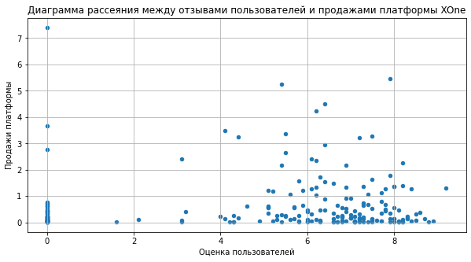

```python
data.query('platform == "XOne"').plot(x='user_score', y='revenue', kind = 'scatter',figsize=(10, 5), grid=True)
plt.title('Диаграмма рассеяния между отзывами пользователей и продажами платформы XOne')
plt.xlabel('Оценка пользователей')
plt.ylabel('Продажи платформы')
plt.show()
```

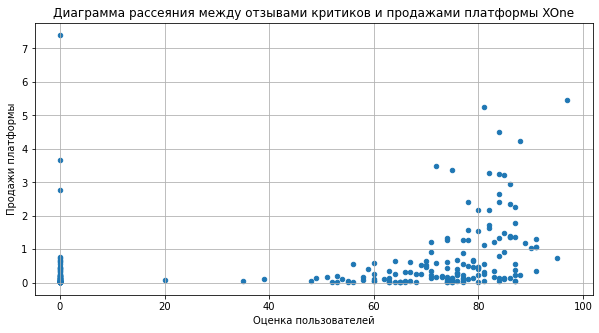

```python
data.query('platform == "XOne"').plot(x='critic_score', y='revenue', kind = 'scatter',figsize=(10, 5), grid=True)
plt.title('Диаграмма рассеяния между отзывами критиков и продажами платформы XOne')
plt.xlabel('Оценка пользователей')
plt.ylabel('Продажи платформы')
plt.show()
```

```python
XOne_platform = data.query('platform == "XOne"')
XOne_platform = XOne_platform.query('user_score > 0')
XOne_platform = XOne_platform.query('critic_score > 0')
display('Корреляция между отзывами пользователей и продажами', XOne_platform['user_score'].corr(XOne_platform['revenue']))# коэффициент корреляции user_scores
display('Корреляция между отзывами критиков и продажами', XOne_platform['critic_score'].corr(XOne_platform['revenue']))# коэффициент корреляции critic_score
```

```
'Корреляция между отзывами пользователей и продажами'
```

```
-0.09173434503310753
```

```
'Корреляция между отзывами критиков и продажами'
```

```
0.4221118510555768
```

Проверим данные платформы PS4.

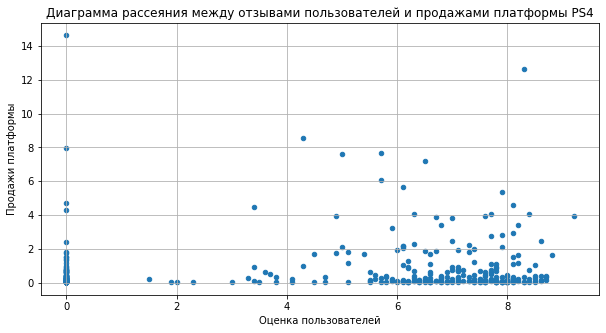

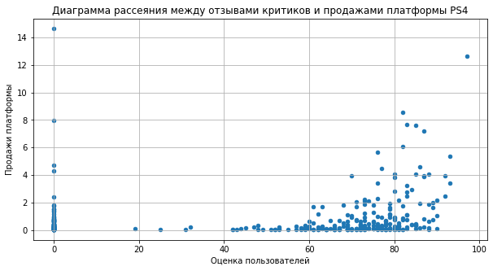

```
'Корреляция между отзывами пользователей и продажами'
```

```
-0.04318585997193627
```

```
'Корреляция между отзывами критиков и продажами'
```

```
0.401902878114753
```

```python
data.query('platform == "PS4"')
data.query('platform == "PS4"').plot(x='user_score', y='revenue', kind = 'scatter',figsize=(10, 5), grid=True)
plt.title('Диаграмма рассеяния между отзывами пользователей и продажами платформы PS4')
plt.xlabel('Оценка пользователей')
plt.ylabel('Продажи платформы')
plt.show()
data.query('platform == "PS4"').plot(x='critic_score', y='revenue', kind = 'scatter',figsize=(10, 5), grid=True)
plt.title('Диаграмма рассеяния между отзывами критиков и продажами платформы PS4')
plt.xlabel('Оценка пользователей')
plt.ylabel('Продажи платформы')
plt.show()
PS4_platform = data.query('platform == "PS4"')
PS4_platform = PS4_platform.query('user_score > 0')
PS4_platform = PS4_platform.query('critic_score > 0')
display('Корреляция между отзывами пользователей и продажами', PS4_platform['user_score'].corr(PS4_platform['revenue']))# коэффициент корреляции user_scores
display('Корреляция между отзывами критиков и продажами', PS4_platform['critic_score'].corr(PS4_platform['revenue']))# коэффициент корреляции critic_score
```

Вывод:

Корреляция между отзывами пользователей и продажами в - 0.09 (XOne), -0.04 (PS4)говорит об отсутствии связи.

Корреляция между отзывами критиков и продажами в 0.42 (XOne), 0.40 (PS4) говорит о наличии связи, однако не слишком сильной. Выходит, высокие отзывы критиков приводят к увеличению прибыли платформы, но так бывает не всегда.

Получается, что отзывы пользователей не влияют на продажи платформы, а отзывы критиков - влияют. Данный вывод применим и на другие платформы.

3.6 Посмотрите на общее распределение игр по жанрам. Что можно сказать о самых прибыльных жанрах? Выделяются ли жанры с высокими и низкими продажами?

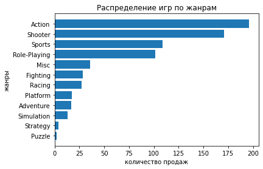

```
genre
Adventure       0.094886
Strategy        0.107027
Puzzle          0.209000
Simulation      0.323000
Action          0.337997
Misc            0.356238
Racing          0.413182
Role-Playing    0.459005
Fighting        0.485172
Platform        0.519412
Sports          0.722450
Shooter         1.387967
Name: revenue, dtype: float64
```

```python
genre_group = data.groupby('genre')['revenue'].sum().reset_index()
genre_group.columns = ['genre', 'revenue_sum']
genre_group = genre_group.sort_values(by='revenue_sum')
fig, ax = plt.subplots()
plt.barh(genre_group['genre'], genre_group['revenue_sum'])
ax.set_title('Распределение игр по жанрам')
ax.set_xlabel('количество продаж')
ax.set_ylabel('жанры')
plt.show()
display(data.groupby('genre')['revenue'].mean().sort_values())
```

Среднее значение продаж указывает на то, что высокий показатель у жанра Shooter, далее Sports, Platform. Однако наибольшую прибыль принес жанр Action, хотя среднее значение продаж небольшое. Следовательно, большие продажи в Action связаны с большим количеством выпущенных игр.

**Шаг 4. Составьте портрет пользователя каждого региона**

4.1 Пользователь региона NA:

- Самые популярные платформы (топ-5). Опишите различия в долях продаж.
- Самые популярные жанры (топ-5). Поясните разницу.
- Влияет ли рейтинг ESRB на продажи в отдельном регионе?

4.1.1 Найдем самые популярные платформы (топ-5).

```python
na_platforms = data.pivot_table( index='platform', values = 'na_sales', aggfunc='sum').sort_values(by = 'na_sales', ascending = False).reset_index()
na_platforms.columns = ['platform', 'na_sales_sum']
display(na_platforms)
```

|  | platform | na_sales_sum |
| --- | --- | --- |
| 0 | PS4 | 98.49 |
| 1 | XOne | 80.92 |
| 2 | X360 | 27.54 |
| 3 | 3DS | 22.23 |
| 4 | PS3 | 21.82 |
| 5 | WiiU | 19.16 |
| 6 | PC | 7.23 |
| 7 | PSV | 2.51 |
| 8 | Wii | 1.16 |
| 9 | PSP | 0.00 |

```python
na_sales_total = na_platforms['na_sales_sum'].sum()
display(na_sales_total)
na_platforms['ratio'] = na_platforms['na_sales_sum']/na_sales_total
display(na_platforms.head(5))
```

```
281.06
```

|  | platform | na_sales_sum | ratio |
| --- | --- | --- | --- |
| 0 | PS4 | 98.49 | 0.350423 |
| 1 | XOne | 80.92 | 0.287910 |
| 2 | X360 | 27.54 | 0.097986 |
| 3 | 3DS | 22.23 | 0.079093 |
| 4 | PS3 | 21.82 | 0.077635 |

Топ 5 платформ по продажам в Северной Америке - PS4 (доля продаж 35%), XOne (доля продаж 28.7%), X360 (доля продаж 9.7%), 3DS (доля продаж 7.9%), PS3 (доля продаж 7.7%).

4.1.2 Найдем самые популярные жанры (топ-5) в Северной Америке

```python
na_genre = data.pivot_table( index='genre', values = 'na_sales', aggfunc='sum').sort_values(by = 'na_sales', ascending = False)
display(na_genre)
```

| genre | na_sales |
| --- | --- |
| Shooter | 78.89 |
| Action | 71.17 |
| Sports | 46.03 |
| Role-Playing | 33.47 |
| Misc | 14.31 |
| Fighting | 12.41 |
| Racing | 8.65 |
| Platform | 6.61 |
| Adventure | 5.36 |
| Simulation | 2.59 |
| Strategy | 0.98 |
| Puzzle | 0.59 |

Наиболее популярные жанры в Северной Америке по данным продаж (в порядке убывания) это Shooter, Action, Sports, Pole-Playing, Misc.

4.1.3 Выясним, влияет ли рейтинг ESRB на продажи в Северной Америке.

```python
na_rating = data.pivot_table( index='rating', values = 'na_sales', aggfunc='sum').sort_values(by = 'na_sales', ascending = False)
display(na_rating)
```

| rating | na_sales |
| --- | --- |
| M | 96.36 |
| Unknown | 64.68 |
| E | 50.25 |
| T | 38.76 |
| E10+ | 31.01 |

Наиболее популярными в Северной Америке являются игры с рейтингом:

- M - Mature/Для взрослых,
- Unknown,
- E - Everyone/Для всех,
- T - Teen/Подросткам,
- E10+ - Everyone 10 and older/Для всех от 10 лет и старше.

Найдем самые популярные платформы (топ-5), жанры (топ-5), рейтинг ESRB в Европе и Японии

```python
country = ['eu_sales', 'jp_sales']

for c in country:
    country_platforms = data.pivot_table( index='platform', values = f"{c}", aggfunc='sum').sort_values(by = f"{c}", ascending = False).reset_index()
    country_platforms.columns = ['platform', f"{c}"]
    country_sales_total = country_platforms[f"{c}"].sum()
    country_platforms['ratio'] = country_platforms[f"{c}"]/country_sales_total
    display(country_platforms.head(5))

    country_genre = data.pivot_table( index='genre', values = f"{c}", aggfunc='sum').sort_values(by = f"{c}", ascending = False)
    display(country_genre.head(5))

    country_rating = data.pivot_table( index='rating', values = f"{c}", aggfunc='sum').sort_values(by = f"{c}", ascending = False)
    display(country_rating)
```

|  | platform | eu_sales | ratio |
| --- | --- | --- | --- |
| 0 | PS4 | 130.04 | 0.486750 |
| 1 | XOne | 46.09 | 0.172518 |
| 2 | PS3 | 24.97 | 0.093465 |
| 3 | PC | 17.88 | 0.066926 |
| 4 | 3DS | 15.42 | 0.057718 |

| genre | eu_sales |
| --- | --- |
| Action | 73.15 |
| Shooter | 65.44 |
| Sports | 45.48 |
| Role-Playing | 28.17 |
| Racing | 14.03 |

| rating | eu_sales |
| --- | --- |
| M | 93.42 |
| Unknown | 58.74 |
| E | 57.44 |
| T | 33.93 |
| E10+ | 23.63 |

|  | platform | jp_sales | ratio |
| --- | --- | --- | --- |
| 0 | 3DS | 44.13 | 0.477081 |
| 1 | PS4 | 15.02 | 0.162378 |
| 2 | PSV | 14.43 | 0.156000 |
| 3 | PS3 | 10.85 | 0.117297 |
| 4 | WiiU | 7.31 | 0.079027 |

| genre | jp_sales |
| --- | --- |
| Role-Playing | 31.16 |
| Action | 29.11 |
| Fighting | 6.34 |
| Misc | 5.61 |
| Shooter | 4.87 |

| rating | jp_sales |
| --- | --- |
| Unknown | 56.90 |
| T | 14.32 |
| E | 8.94 |
| M | 8.01 |
| E10+ | 4.33 |

4.2 Пользователь региона EU:

- Топ 5 платформ по продажам в Европе - PS4 (доля продаж 48.6%), XOne (доля продаж 17.2%), PS3 (доля продаж 9.3%), PC (доля продаж 6.6%), 3DS (доля продаж 5.7%).
- Наиболее популярные жанры в Европе по данным продаж (в порядке убывания) это Action, Shooter, Sports, Pole-Playing, Racing.
- Наиболее популярными в Европе являются игры с рейтингом:
- M - Mature/Для взрослых,
- Неизвестный ретинг,
- E - Everyone/Для всех,
- T - Teen/Подросткам,
- E10+ - Everyone 10 and older/Для всех от 10 лет и старше.

4.3 Пользователь региона JP:

- Топ 5 платформ по продажам в Японии - 3DS (доля продаж 47.7%), PS4 (доля продаж 16.2%), PSV (доля продаж 15.6%), PS3 (доля продаж 11.7%), WiiU (доля продаж 7.9%).
- Наиболее популярные жанры в Японии по данным продаж (в порядке убывания) это Pole-Playing, Action, Fighting, Misc, Shooter.
- Наиболее популярными в Японии являются игры с рейтингом:
- Неизвестный ретинг,
- T - Teen/Подросткам,
- E - Everyone/Для всех,
- M - Mature/Для взрослых,
- E10+ - Everyone 10 and older/Для всех от 10 лет и старше.

Вывод: регион влияет на выбор платформы, жанра и рейтинга игры.

**Шаг 5. Проверьте гипотезы**

5.1 Средние пользовательские рейтинги платформ Xbox One и PC одинаковые. Задайте самостоятельно пороговое значение alpha. Поясните:

- Как вы сформулировали нулевую и альтернативную гипотезы;
- Какой критерий применили для проверки гипотез и почему.

Нулевая гипотеза (H0): Средние пользовательские рейтинги (user_score) платформ Xbox One и PC одинаковые.

Альтернативная гипотеза (H1): Средние пользовательские рейтинги платформ Xbox One и PC не одинаковые. aplha = 0.05

Применим t-тест (ttest_ind) для сравнения средних значений двух выборок двух независимых групп, чтобы определить, существует ли различие между ними.

```python
XOne_data = data.query('platform == "XOne"').reset_index()
PC_data = data.query('platform == "PC"').reset_index()
```

```python
alpha = 0.05 # уровень статистической значимости. Если p-value окажется меньше него, то отвергнет гипотезу
results = st.ttest_ind(PC_data['user_score'], XOne_data['user_score'])

print('p-значение', results.pvalue)

if results.pvalue < alpha:
    print('Отвергаем нулевую гипотезу')
else:
    print('Не получилось отвергнуть нулевую гипотезу')
```

```
p-значение 0.43391295385945705
Не получилось отвергнуть нулевую гипотезу
```

Вывод: не получилось отвергнуть Н0, т.е. средние пользовательские рейтинги (user_score) платформ Xbox One и PC одинаковые.

5.2 Средние пользовательские рейтинги жанров Action (англ. «действие», экшен-игры) и Sports (англ. «спортивные соревнования») разные. Задайте самостоятельно пороговое значение alpha. Поясните:

- Как вы сформулировали нулевую и альтернативную гипотезы;
- Какой критерий применили для проверки гипотез и почему.

Нулевая гипотеза (H0): Средние пользовательские рейтинги жанров Action и Sports одинаковые.

Альтернативная гипотеза (H1): Средние пользовательские рейтинги жанров Action и Sports разные.

aplha = 0.05

Применим t-тест (ttest_ind) для сравнения средних значений двух выборок двух независимых групп, чтобы определить, существует ли различие между ними.

```python
Action_data = data.query('genre == "Action"').reset_index()
Sports_data = data.query('genre == "Sports"').reset_index()
```

```python
alpha = 0.05 # уровень статистической значимости. Если p-value окажется меньше него, то отвергнет гипотезу
results = st.ttest_ind(Action_data['user_score'], Sports_data['user_score'])

print('p-значение', results.pvalue)

if results.pvalue < alpha:
    print('Отвергаем нулевую гипотезу')
else:
    print('Не получилось отвергнуть нулевую гипотезу')
```

```
p-значение 0.0025336816968133196
Отвергаем нулевую гипотезу
```

Вывод: Отвергаем Н0, получается, что средние пользовательские рейтинги жанров Action и Sports разные.

**Шаг 6. Общий вывод**

Исходный датафрейм содержал данные с 1980 года по 2016 год. Датафрейм был проверен на дубликаты, пропуски, аномальные значения. Выявленные недочеты были устранены или заменены.

Для анализа была взята часть данных с 2014 года до 2016 год, т.к. сфера игр быстро меняющаяся. С 1980 год до 2016 года было всего 31 платформа, к 2014 году осталось 10. Исходя из графиков продаж, видно, что новые платформы набирают популярность в течение 2-х лет, далее выручка идет на убыль. Когда появляются новые платформы, старые теряют популярность, велик риск, что в такие моменты старые платформы могут уйти с рынка. Наиболее перспективные платформы по прибыли на 2016 год - XOne, PS4, 3DS.

Были оценены влияние отзывов пользователей и критиков на продажи платформы. Существует корреляция между отзывами критиков и продажами, однако не слишком сильной. Выходит, высокие отзывы критиков приводят к увеличению прибыли платформы, но так бывает не всегда. Корреляция между отзывами пользователей и продажами отсутствует. Получается, что отзывы пользователей не влияют на продажи платформы, а отзывы критиков - влияют.

Топ 5 популярных жанров (по убыванию) Action, Shooter, Sports, Pole-playing, Misc. Но данный рейтинг меняется в зависимости от региона. Например, в Японии самым популярным жанром является Pole-Playing. Жанры с низкими продажами оказались Adventure, Strategy.